# HW7

Cheng Zhong, 16307110259

2019年4月22日

- **0、数据预处理**-

```r
# 清除工作环境
cat("\014");rm(list=ls())
```

```r
setwd('E:\\Rdata')
library(pROC)
library(ROCR)
hotpot <- read.csv("HotPotForMac.csv",fileEncoding = 'UTF-8',sep = ',',stringsAsFactors = TRUE)  # 读入文件

hotpot$logquarterly.sales.volume <- log(hotpot$quarterly.sales.volume + 1)
a <- mean(hotpot$logquarterly.sales.volume)
hotpot$high <- 0
hotpot$high[hotpot$quarterly.sales.volume >= a] <- 1                            #以平均对数销售量为分界线确定高低水平

hotpot$privilege.for.new <- factor(hotpot$privilege.for.new,levels = c("无钱包新客优惠","钱包新客最高再减20元","有立减优惠"))
hotpot$parking <- factor(hotpot$parking,levels = c("免费停车位","收费停车位","无停车位","未提及"))
hotpot$style <- factor(hotpot$style,levels = c("其他","北系","川系","粤系"))
hotpot$district <- factor(hotpot$district,levels = c("临潼区","新城区","未央区","灞桥区","碑林区","莲湖区","长安区","阎良区","雁塔区","高新区"))

hotpot$logprice <- log(hotpot$price) #将价格取对数使其更加密集
hotpot <- hotpot[,-c(1,2,3,5,6,16,18,28)]  #去掉一些无关变量，如店名字段，销售量，评论数

set.seed(17)
library(caret)
N = length(hotpot$high)
folds <- createFolds(y = hotpot[,1],k=10)
```

先对数据进行处理，去除无关变量,如店名字段，销售量，评论数，以平均对数销售量为分界线区分销售量的高低水平。本题中，我们采用简单交叉验证的方法测试四种模型的拟合程度,同时采用十折交叉验证进行分组。

```r
AUC_value <- as.numeric()
accuracy <- as.numeric()
precision <- as.numeric()
recall <- as.numeric()
for (i in  1:10)
{
hotpot_train <- hotpot[-folds[[i]],]
hotpot_test <- hotpot[folds[[i]],]         #循环选取数据的十分之一作为测试集，其他作为验证集

pre <- glm(formula = high ~ . ,data = hotpot_train)

real <- hotpot_test$high
predict. <- predict.glm(pre,type='response',newdata=hotpot_test)
predict = ifelse(predict.>0.5,1,0)
hotpot_test$predict <- predict  #计算验证集的取值


#判断模型精确度
predict <- hotpot_test$predict
real <- hotpot_test$high
error <- predict - real
accuracy[i] <- (nrow(hotpot_test) - sum(abs(error)))/nrow(hotpot_test)#准确率
precision[i] <- sum(real & predict)/sum(predict)  #查全率
recall[i] <- sum(predict & real)/sum(real)  #查准率
pred <- prediction(predict.,real)
AUC_value[i] <- as.numeric(performance(pred,'auc')@y.values[1])        #AUC值
}
cat('Confusion Matrix:\n')
```

```
## Confusion Matrix:
```

```r
table(real,predict) #以最后一例计算混淆矩阵
```

```
##     predict
## real   0   1
##    0  66  15
##    1  18 169
```

```r
#ROC曲线

library(ROCR)

cat('MeanRecall = ',mean(recall),'\n')
```

```
## MeanRecall =  0.9148626
```

```r
cat('MeanPrecision = ',mean(precision),'\n')
```

```
## MeanPrecision =  0.8792903
```

```r
cat('MeanAccuracy = ',mean(accuracy),'\n')
```

```
## MeanAccuracy =  0.857164
```

```r
cat('MeanAUC = ',mean(AUC_value) )
```

```
## MeanAUC =  0.8670029
```

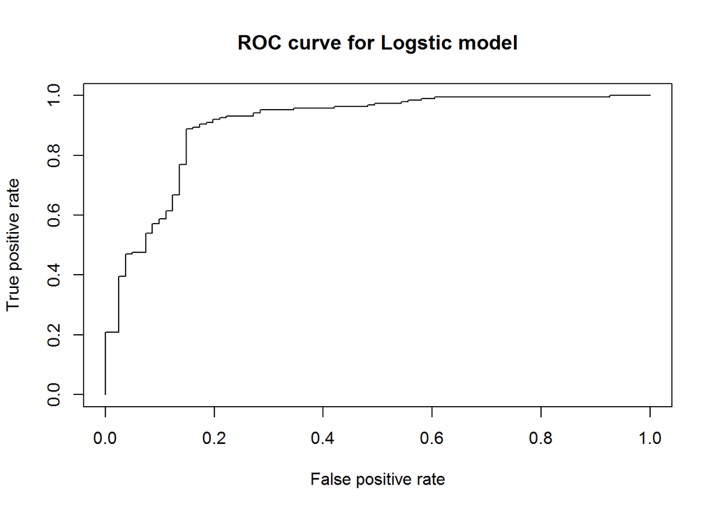

```r
perf <- performance(pred,'tpr','fpr') #以最后一例画ROC曲线
plot(perf,main = 'ROC curve for Logstic model')
```

绘制ROC曲线，计算出AUC值也在0.87左右，故可以判断出逻辑斯蒂模型在验证集上的回归效果较好。

–**2、LDA模型**-

```r
AUC_value <- as.numeric()
accuracy <- as.numeric()
precision <- as.numeric()
recall <- as.numeric()
for (i in  1:10)
{
hotpot_train <- hotpot[-folds[[i]],]
hotpot_test <- hotpot[folds[[i]],]         #循环选取数据的十分之一作为测试集，其他作为验证集
library(MASS)
ff1 <- lda(high ~ . , hotpot_train) #以LDA模型进行拟合
head(ff1)
ff2=predict(ff1,hotpot_test)    #预测验证集中的结果
hotpot_test$predict <- ff2$class

#判断模型精确度
predict <- as.numeric(hotpot_test$predict) - 1
real <- hotpot_test$high
error <- predict - real
accuracy[i] <- (nrow(hotpot_test) - sum(abs(error)))/nrow(hotpot_test)
precision[i] <- sum(real & predict)/sum(predict)
recall[i] <- sum(predict & real)/sum(real)
pred <- prediction(ff2$posterior[,2],real)
AUC_value[i] <- as.numeric(performance(pred,'auc')@y.values[1])        #AUC值
}
cat('Confusion Matrix:\n')
```

```
## Confusion Matrix:
```

```r
table(real,predict) #混淆矩阵
```

```
##     predict
## real   0   1
##    0  66  15
##    1  18 169
```

```r
#ROC曲线

library(ROCR)

cat('MeanRecall = ',mean(recall),'\n')
```

```
## MeanRecall =  0.9142945
```

```r
cat('MeanPrecision = ',mean(precision),'\n')
```

```
## MeanPrecision =  0.879208
```

```r
cat('MeanAccuracy = ',mean(accuracy),'\n')
```

```
## MeanAccuracy =  0.8567923
```

```r
cat('MeanAUC = ',mean(AUC_value) )
```

```
## MeanAUC =  0.8670029
```

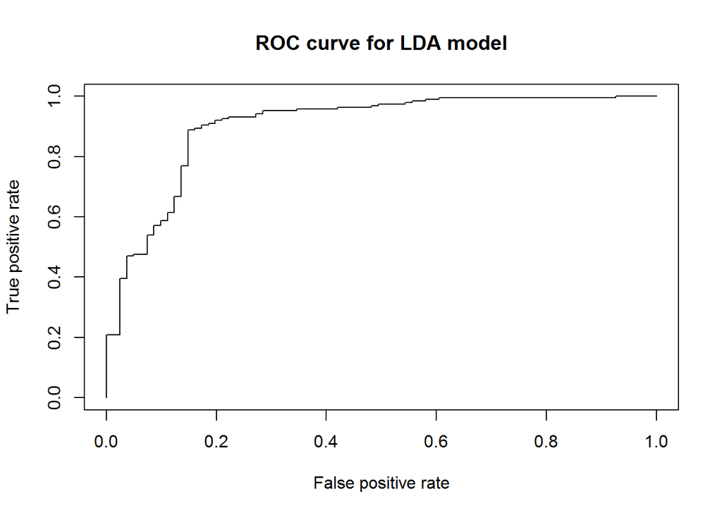

```r
perf <- performance(pred,'tpr','fpr') #以最后一例画ROC曲线
plot(perf,main = 'ROC curve for LDA model')
```

从模型拟合的结果来看，通过LDA模型进行拟合，在验证集上,模型的查准率、查全率、准确率在0.87上下浮动

绘制ROC曲线，计算出AUC值约为0.86，故可以判断出LDA在数据集上也能取得不错的回归效果。

–**3、朴素贝叶斯**–

我们再尝试着运用朴素贝叶斯模型对数据集进行拟合

```r
#NB
AUC_value <- as.numeric()
accuracy <- as.numeric()
precision <- as.numeric()
recall <- as.numeric()
for (i in  1:10)
{
hotpot_train <- hotpot[-folds[[i]],]
hotpot_test <- hotpot[folds[[i]],]         #循环选取数据的十分之一作为测试集，其他作为验证集

hotpot_train$high <- as.factor(hotpot_train$high)  #这里要把factor设置为factor类型否则会报错

hotpot_test$high <- as.factor(hotpot_test$high)

library(klaR)

nb.model <- NaiveBayes(high ~ ., data = hotpot_train)
nb_predict <- predict(nb.model, newdata =  hotpot_test)
hotpot_test$predict <- as.numeric(nb_predict$class) - 1
hotpot_test$high <- as.numeric(hotpot_test$high) - 1

predict <- as.numeric(hotpot_test$predict)
real <- as.numeric(hotpot_test$high)
error <- predict - real
accuracy[i] <- (nrow(hotpot_test) - sum(abs(error)))/nrow(hotpot_test)
precision[i] <- sum(real & predict)/sum(predict)
recall[i] <- sum(predict & real)/sum(real)
pred <- prediction(as.numeric(nb_predict$posterior[,2]),real)
AUC_value[i] <- as.numeric(performance(pred,'auc')@y.values[1])        #AUC值
}
cat('Confusion Matrix:\n')
```

```
## Confusion Matrix:
```

```r
table(real,predict) #混淆矩阵
```

```
##     predict
## real   0   1
##    0  66  15
##    1  19 168
```

```r
#ROC曲线

library(ROCR)

pred <- prediction(as.numeric(nb_predict$posterior[,2]),real)

cat('MeanRecall = ',mean(recall),'\n')
```

```
## MeanRecall =  0.9126226
```

```r
cat('MeanPrecision = ',mean(precision),'\n')
```

```
## MeanPrecision =  0.8781248
```

```r
cat('MeanAccuracy = ',mean(accuracy),'\n')
```

```
## MeanAccuracy =  0.854939
```

```r
cat('MeanAUC = ',mean(AUC_value) )
```

```
## MeanAUC =  0.8733435
```

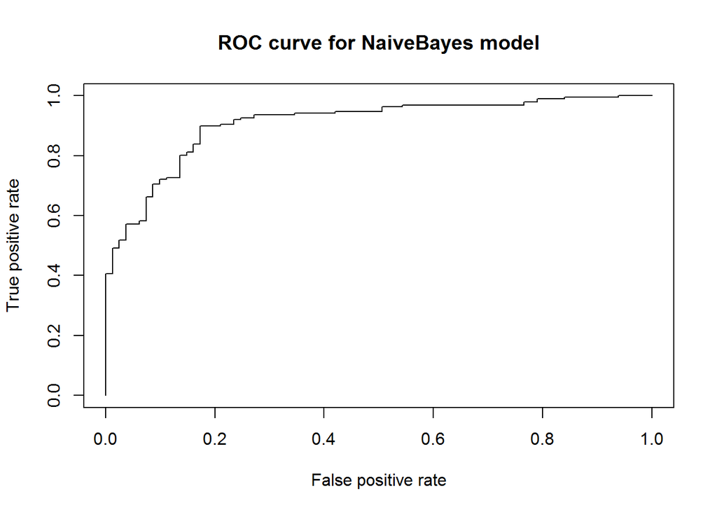

```r
perf <- performance(pred,'tpr','fpr') #以最后一例画ROC曲线
plot(perf,main = 'ROC curve for NaiveBayes model')
```

从模型拟合的结果来看，通过朴素贝叶斯模型进行拟合，在验证集上,模型的查准率、查全率、准确率在0.86上下浮动

–**4、KNN**–

最后我们使用k-近邻算法对数据集进行拟合

```r
library(kknn)
AUC_value <- as.numeric()
accuracy <- as.numeric()
precision <- as.numeric()
recall <- as.numeric()
for (i in  1:10)
{
hotpot_train <- hotpot[-folds[[i]],]
hotpot_test <- hotpot[folds[[i]],]         #循环选取数据的十分之一作为测试集，其他作为验证集
model.knn <- kknn(high~., hotpot_train, hotpot_test)

predict. <- model.knn[["fitted.values"]] #归类的概率
predict = ifelse(predict.>0.5,1,0)

real <- as.numeric(hotpot_test$high)
error <- predict - real
accuracy[i] <- (nrow(hotpot_test) - sum(abs(error)))/nrow(hotpot_test)
precision[i] <- sum(real & predict)/sum(predict)
recall[i] <- sum(predict & real)/sum(real)
pred <- prediction(predict.,real)
AUC_value[i] <- as.numeric(performance(pred,'auc')@y.values[1])        #AUC值
}

cat('Confusion Matrix:\n')
```

```
## Confusion Matrix:
```

```r
table(real,predict) #混淆矩阵
```

```
##     predict
## real   0   1
##    0  61  20
##    1  19 168
```

```r
#ROC曲线

library(ROCR)

cat('MeanRecall = ',mean(recall),'\n')
```

```
## MeanRecall =  0.8980649
```

```r
cat('MeanPrecision = ',mean(precision),'\n')
```

```
## MeanPrecision =  0.8768932
```

```r
cat('MeanAccuracy = ',mean(accuracy),'\n')
```

```
## MeanAccuracy =  0.8452583
```

```r
cat('MeanAUC = ',mean(AUC_value) )
```

```
## MeanAUC =  0.8830661
```

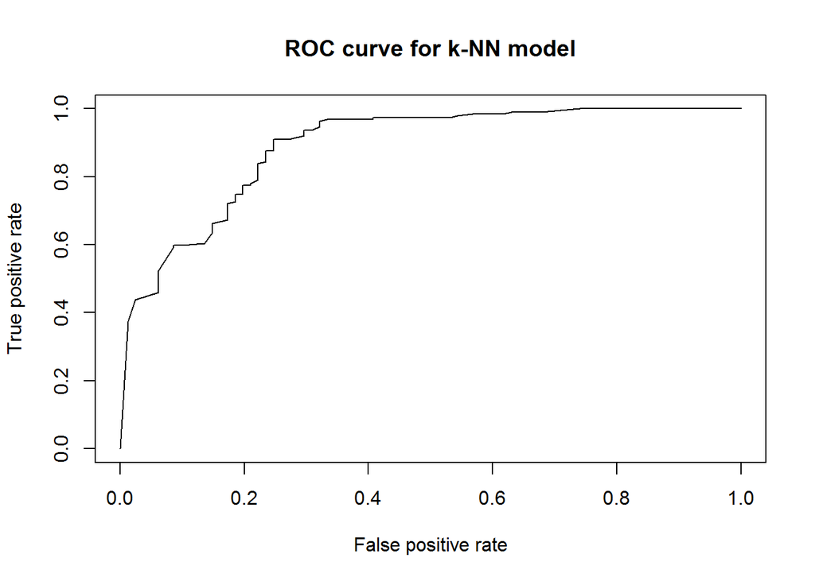

```r
perf <- performance(pred,'tpr','fpr') #以最后一例画ROC曲线
plot(perf,main = 'ROC curve for k-NN model')
```

从模型拟合的结果来看，通过k-近邻模型进行拟合，在验证集上,模型的查准率、查全率、准确率在0.87上下浮动

绘制ROC曲线，计算出AUC值约为0.88，故认为k-近邻模型在数据集上的拟合效果较优。

通过对四种拟合方法的实验，我们可以作出总结，逻辑斯蒂回归、LDA、朴素贝叶斯、k-近邻模型都可以在火锅数据集上对团购水平作出较好的估计。